# R Notebook

# Advanced ggplot homework

```r
library(tidyverse)
library(CodeClanData)
library(ggthemes)
library(extrafont)
fonts()
```

[output not shown]

[output cut: 35 more lines]

```r
col_scheme <- c("#E89FE9", "#50434F", "#B6A7B5", "#F9A472", "#BD7040")

company_theme <- theme_bw(base_size = 12, base_family = "Trebuchet MS") +
  theme(
        panel.border     = element_blank(),
        panel.background = element_rect(fill   = "white",  colour = "white"),
        panel.grid.major = element_line(colour = "grey95", size   = 0.5),
        panel.grid.minor = element_line(colour = "grey95", size   = 0.5)
)
```

1. Take the data in the dataset qb_revenue_breakdown and make a stacked bar chart showing the sources of revenue across the two years in the dataset.

```r
qb_revenue_breakdown
```

| Product | Year | Revenue |
| --- | --- | --- |
| Trackers | 2019 | 8994 |
| Smart Watches | 2019 | 12003 |
| Accessories | 2019 | 5250 |
| Subscription Services | 2019 | 3750 |
| Trackers | 2018 | 8004 |
| Smart Watches | 2018 | 11000 |
| Accessories | 2018 | 4250 |
| Subscription Services | 2018 | 1005 |

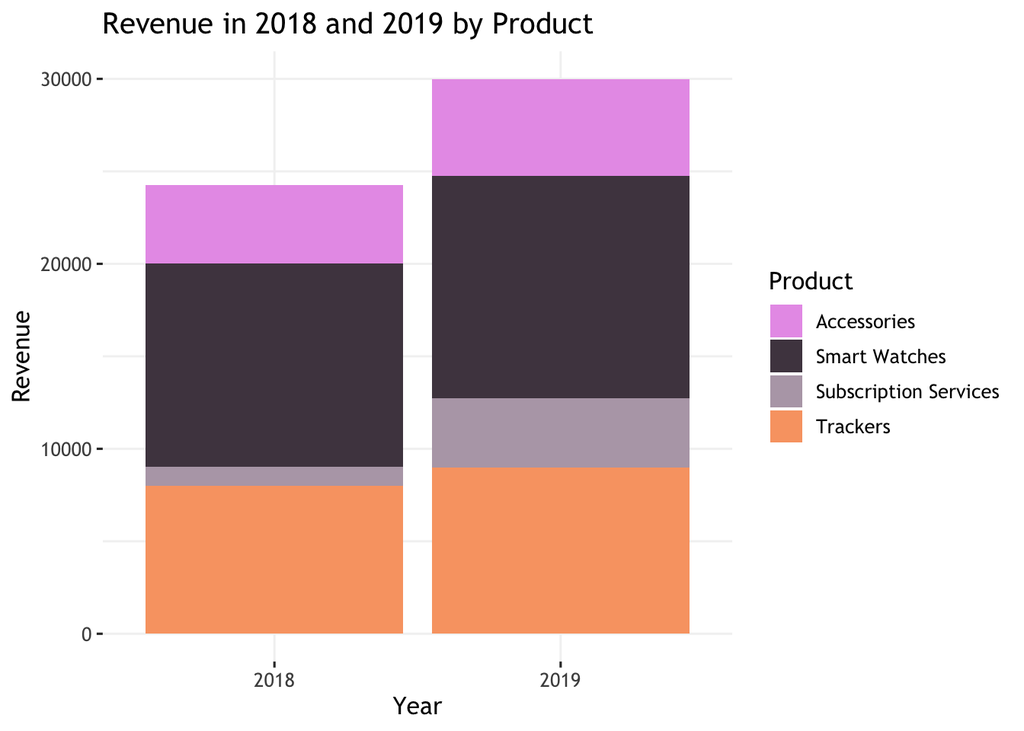

```r
ggplot(qb_revenue_breakdown) +
  aes(x = Year, y = Revenue, fill = Product) +
  geom_col(position = "stack") +
  scale_fill_manual(values = col_scheme) +
  company_theme +
  labs(
    title = "Revenue in 2018 and 2019 by Product"
  )
```

2. Make a line chart showing monthly sales of the “flagship product” - the KwikBit Unit1 - over the last year. This data is inside qb_monthly_sales, but you will need to use subset.

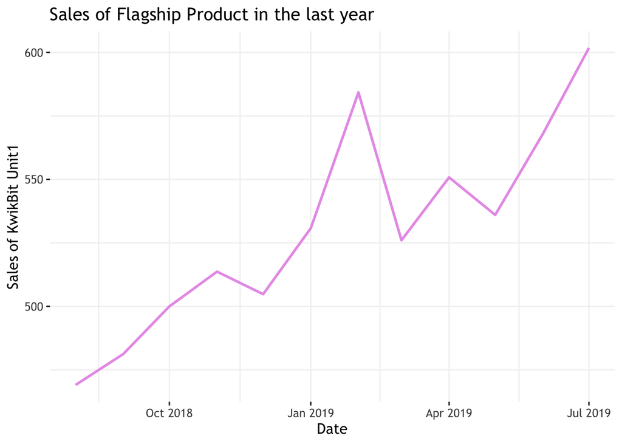

```r
view(qb_monthly_sales)

qb_monthly_sales %>%
  filter(Cashflow == "Kwikbit Unit 1 Sales") %>%
  ggplot() +
  aes(x = Date, y = Amount) +
  geom_line(colour = "#E89FE9", size = 1) +
  labs(
    y     = "Sales of KwikBit Unit1",
    title = "Sales of Flagship Product in the last year"
  ) +
  company_theme
```

3. Make a line chart showing monthly revenue and costs over the last year. This data is also in qb_monthly_sales.

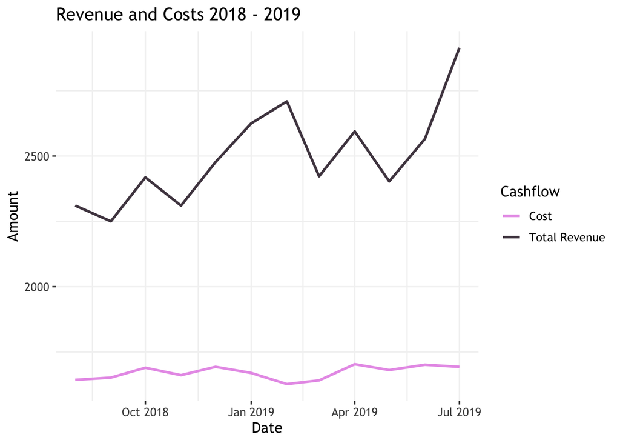

```r
qb_monthly_sales %>%
  filter(Cashflow != "Kwikbit Unit 1 Sales") %>%
  mutate(rev_cost = if_else(Cashflow == "Total Revenue", "Total Revenue", "Cost")) %>%
  ggplot() +
  aes(x = Date, y = Amount, group = rev_cost, colour = Cashflow) +
  geom_line(size = 1)  +
  company_theme +
  scale_colour_manual(values = col_scheme) +
  labs(
    title = "Revenue and Costs 2018 - 2019"
  )
```

4. Show annual sales of personal fitness trackers over the last 5 years broken down by company as a ribbon plot (use geom_area). This data is in qb_competitors.

```r
view(qb_competitors)

qb_competitors %>%
  filter(Year == "2019") %>%
  summarise(sum(Revenue))
```

| sum(Revenue) |
| --- |
| 6660000 |

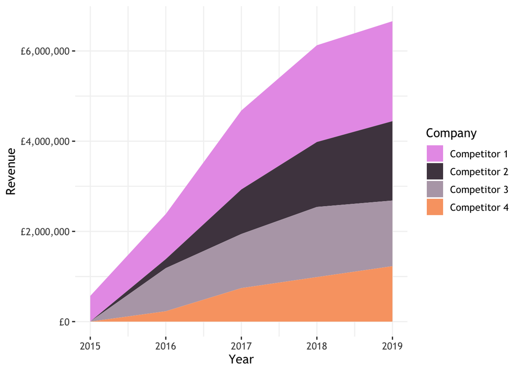

```r
ggplot(qb_competitors) +
  aes(x = Year, y = Revenue, fill = Company) +
  geom_area() +
  company_theme +
  scale_fill_manual(values = col_scheme) +
  scale_y_continuous(labels = scales::dollar_format(prefix = "£"))
```

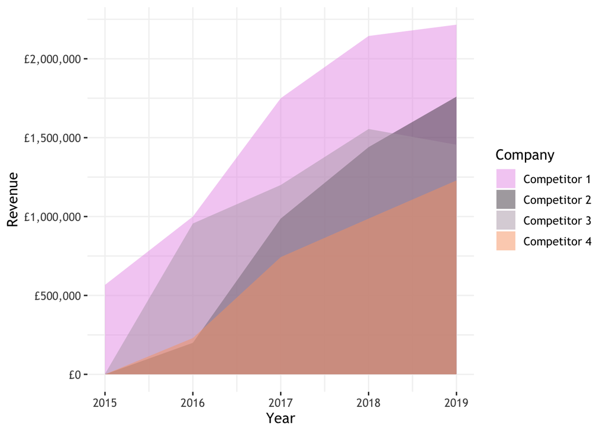

```r
ggplot(qb_competitors) +
  aes(x = Year, y = Revenue, fill = Company) +
  geom_area(position = "identity", alpha = 0.5) +
  company_theme +
  scale_fill_manual(values = col_scheme) +
  scale_y_continuous(labels = scales::dollar_format(prefix = "£"))
```

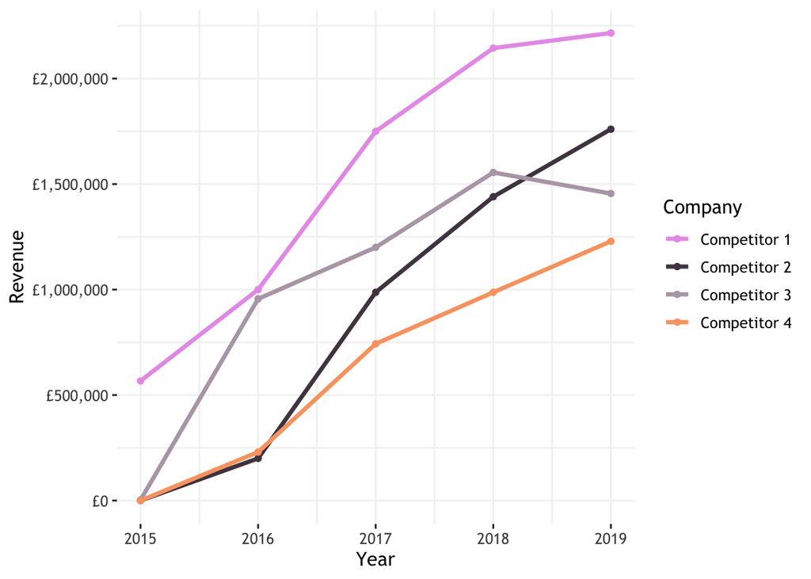

```r
ggplot(qb_competitors) +
  aes(x = Year, y = Revenue, group = Company, colour = Company) +
  geom_line(size = 1.25) +
  geom_point() +
  company_theme +
  scale_colour_manual(values = col_scheme) +
  scale_y_continuous(labels = scales::dollar_format(prefix = "£"))
```

6. Now the company wants to compare the number of steps that their device counts vs. their competitors. Make a line graph of the number of steps throughout time, and use faceting to compare between individuals and devices. Data is in qb_device_data.

```r
view(qb_device_data)

tail(qb_device_data)
```

|  | device | id | hours | mins | counts |
| --- | --- | --- | --- | --- | --- |
| 99783913 | competitor3 | person5 | 19 | 54 | 437 |
| 99783923 | competitor3 | person5 | 19 | 55 | 242 |
| 99783933 | competitor3 | person5 | 19 | 56 | 2223 |
| 99783943 | competitor3 | person5 | 19 | 57 | 0 |
| 99783953 | competitor3 | person5 | 19 | 58 | 0 |
| 99783963 | competitor3 | person5 | 19 | 59 | 0 |

```r
class(qb_device_data)
```

```
## [1] "data.frame"
```

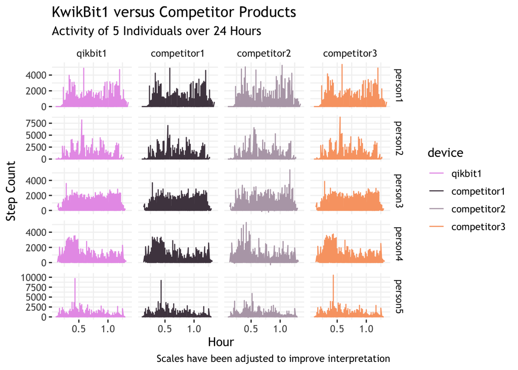

```r
qb_device_data %>%
mutate( decimal_hour = (hours + mins)/60) %>%
ggplot() +
  aes(x = decimal_hour, y = counts, colour = device) +
  geom_line() +
  facet_grid( id ~ device, scales = "free_y") +
  theme_bw(base_size = 12, base_family = "Trebuchet MS") +
  theme(
        strip.background = element_blank(),
        panel.border     = element_blank(),
        panel.background = element_rect(fill   = "white",  colour = "white"),
        panel.grid.major = element_line(colour = "grey95", size   = 0.5),
        panel.grid.minor = element_line(colour = "grey95", size   = 0.5)
) +
  scale_colour_manual(values = col_scheme) +
  labs(
    title    = "KwikBit1 versus Competitor Products",
    subtitle = "Activity of 5 Individuals over 24 Hours",
    x = "Hour",
    y = "Step Count",
    caption = "Scales have been adjusted to improve interpretation"
  )
```